# Revisión de selección de casos: Rehabilitación de infraestructura

2025-05-23

# PREPARAMOS LA DATA

**Autor:** Carlos Mansilla

## Filtraciones para la categoría “rehabilitación”

Importamos la base de datos que se trabajó:

```r
library(rio)
library(kableExtra)
data = import("datos_categorizados3.xlsx")
```

Quitamos los valores irrelevantes que se catalogaron de manera manual:

```r
data <- data[data$CATEGORIA_INV != "NO RELEVANTE", ]
data <- data[data$CATEGORIA_INV != "NO RELACIONADO", ]
```

Para realizar las pruebas, preparo la fecha para realizar el filtrado adecuado:

```r
data$FECHA_REGISTRO <- substr(data$FECHA_REGISTRO, 1, 4)
```

Aquí filtro el año (2019) porque en el estudio se pod´ria visualizar las consecuencias de las paralizaciones de proyectos de inversión por consecuencia del COVID-19:

```r
library(dplyr)
data_filtrada <- data %>%
  filter(FECHA_REGISTRO >= 2019)
```

A partir de esto, filtramos solo la categoría “REHABILITACIÓN”:

```r
library(dplyr)

data_filtrada <- data_filtrada %>%
  filter(CATEGORIA_INV=="REHABILITACIÓN")
```

### Pequeña revisión de las fechas

Ahora revisamos rápidamente cómo ha evolucionado la cantidad de proyectos de inversión sobre la rehabilitación de infraestructura.

```r
proyectos_por_anio <- data_filtrada %>%
  group_by(FECHA_REGISTRO) %>%
  summarise(
    CANTIDAD_PROYECTOS = n()
  ) %>%
  arrange(desc(FECHA_REGISTRO))
```

Revisamos la cantidad por años:

```r
library(knitr)
library(kableExtra)

kable(proyectos_por_anio,
      caption = "Cantidad de proyectos de rehabilitación por año") %>%
  kable_styling(bootstrap_options = c("striped", "hover", "condensed"), full_width = FALSE)
```

Cantidad de proyectos de rehabilitación por año

| FECHA_REGISTRO | CANTIDAD_PROYECTOS |
| --- | --- |
| 2025 | 1 |
| 2024 | 9 |
| 2023 | 1 |
| 2022 | 3 |
| 2021 | 6 |
| 2020 | 3 |
| 2019 | 2 |

Ahora hacemos un gráfico para visualizarlo mejor:

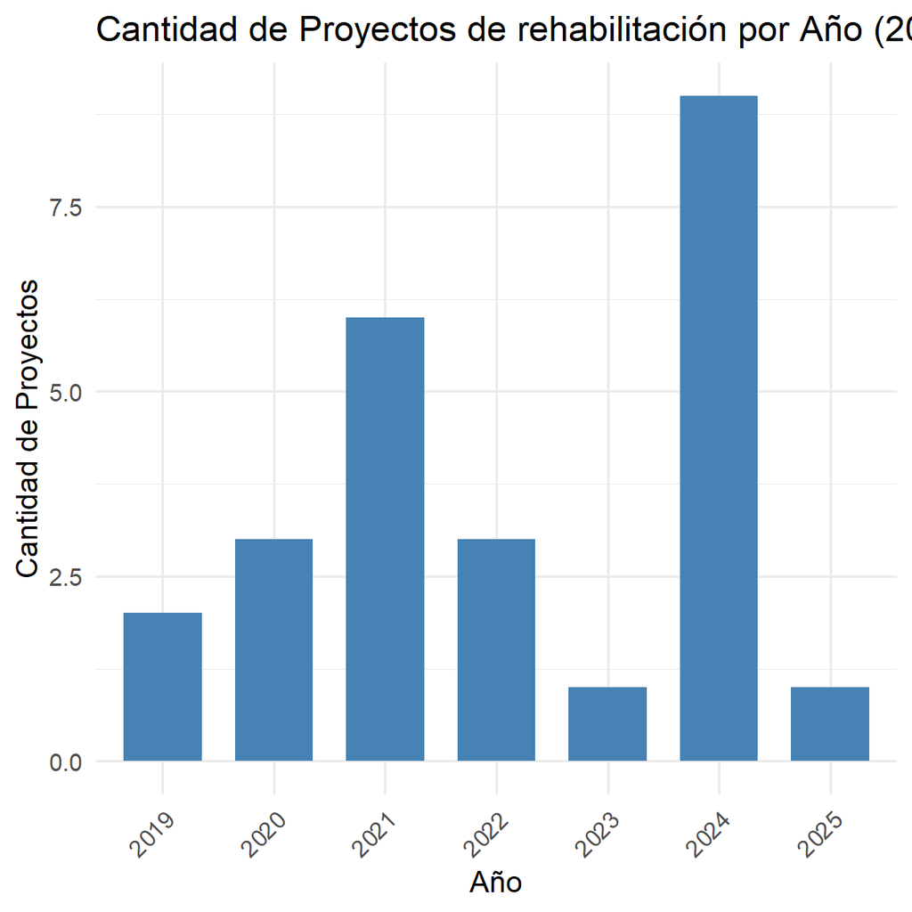

```r
library(ggplot2)
ggplot(proyectos_por_anio, aes(x = as.factor(FECHA_REGISTRO), y = CANTIDAD_PROYECTOS)) +
  geom_bar(stat = "identity", width = 0.7, fill = "steelblue") +
  labs(
    title = "Cantidad de Proyectos de rehabilitación por Año (2019–2025)",
    x = "Año",
    y = "Cantidad de Proyectos"
  ) +
  theme_minimal(base_size = 14) +  # Aumenta el tamaño general del texto
  theme(axis.text.x = element_text(angle = 45, hjust = 1))  # Gira etiquetas del eje X
```

Se observa que la mayor cantidad de datos sobre rehabilitación de infraestructura se encuentra por 2021 y 2024

## Data final: Rehabilitación - reconstrucción

Finalmente, realizamos un vistazo general a los datos filtrados:

```r
kable(data_filtrada,
      caption = "BASE DE DATOS SOBRE INVERSIONES PÚBLICAS DE REHABILITACIÓN DE INFRAESTRUCTURA EDUCATIVA") %>%
  kable_styling(bootstrap_options = c("striped", "hover", "condensed"), full_width = FALSE)
```

BASE DE DATOS SOBRE INVERSIONES PÚBLICAS DE REHABILITACIÓN DE INFRAESTRUCTURA EDUCATIVA

| NIVEL | SECTOR | ENTIDAD | CUI | COD_SNIP | CATEGORIA_INV | NOMBRE_INVERSION | NOMBRE_OPMI | NOMBRE_UF | NOMBRE_UEI | NOMBRE_UEP | ESTADO | SITUACION | MONTO_VIABLE | COSTO_ACTUALIZADO | CTRL_CONCURR | MONTO_LAUDO | MONTO_FIANZA | FECHA_REGISTRO | FECHA_VIABILIDAD | FUNCION | PROGRAMA | SUBPROGRAMA | MARCO | TIPO_INVERSION | DES_MODALIDAD | EXPEDIENTE_TECNICO | INFORME_CIERRE | TIENE_F9 | FEC_REG_F9 | … |
| --- | --- | --- | --- | --- | --- | --- | --- | --- | --- | --- | --- | --- | --- | --- | --- | --- | --- | --- | --- | --- | --- | --- | --- | --- | --- | --- | --- | --- | --- | --- |
| GL | GOBIERNOS LOCALES | MUNICIPALIDAD DISTRITAL DE ANCHIHUAY | 2520546 | 2520546 | REHABILITACIÓN | RENOVACION DE AULA DE EDUCACION INICIAL, MURO DE CONTENCION, SERVICIOS HIGIENICOS Y/O VESTIDORES Y CERCO PERIMETRICO; ADEMÁS DE OTROS ACTIVOS EN EL(LA) IE 425-17 - ANCHIHUAY EN LA LOCALIDAD SAN JOSE, … | OPMI DE LA MUNICIPALIDAD DISTRITAL DE ANCHIHUAY | UF DE LA MUNICIPALIDAD DISTRITAL DE ANCHIHUAY | UEI DE LA MUNICIPALIDAD DISTRITAL DE ANCHIHUAY | MUNICIPALIDAD DISTRITAL DE ANCHIHUAY | DESACTIVADO PERMANENTE | APROBADO | 686913.50 | 686913.50 | 0 | 0 | 0 | 2021 | 2021-06-08 | EDUCACIÓN | EDUCACIÓN BÁSICA | EDUCACIÓN INICIAL | INVIERTE | INVERSIONES IOARR | ADMINISTRACIÓN INDIRECTA - POR CONTRATA- | NO | NO | NA | NA | … |
| GL | GOBIERNOS LOCALES | MUNICIPALIDAD DISTRITAL DE ANCHIHUAY | 2520554 | 2520554 | REHABILITACIÓN | RENOVACION DE AULA DE EDUCACION PRIMARIA, AMBIENTE ADMINISTRATIVO, CERCO PERIMETRICO Y SERVICIOS HIGIENICOS Y/O VESTIDORES; ADEMÁS DE OTROS ACTIVOS EN EL(LA) IE 38724 - ANCHIHUAY EN LA LOCALIDAD BUENA… | OPMI DE LA MUNICIPALIDAD DISTRITAL DE ANCHIHUAY | UF DE LA MUNICIPALIDAD DISTRITAL DE ANCHIHUAY | UEI DE LA MUNICIPALIDAD DISTRITAL DE ANCHIHUAY | MUNICIPALIDAD DISTRITAL DE ANCHIHUAY | DESACTIVADO PERMANENTE | APROBADO | 1749026.12 | 1749026.12 | 0 | 0 | 0 | 2021 | 2021-06-08 | EDUCACIÓN | EDUCACIÓN BÁSICA | EDUCACIÓN PRIMARIA | INVIERTE | INVERSIONES IOARR | ADMINISTRACIÓN INDIRECTA - POR CONTRATA- | NO | NO | NA | NA | … |
| GL | GOBIERNOS LOCALES | MUNICIPALIDAD DISTRITAL DE ANCHIHUAY | 2664063 | 2664063 | REHABILITACIÓN | RENOVACION DE AULA DE EDUCACION INICIAL Y AMBIENTE ADMINISTRATIVO ADQUISICION DE MOBILIARIO DE AULA Y EQUIPAMIENTO DE AULA EN EL(LA) INSTITUCION EDUCATIVA INICIAL Nº 425-27 EN EL CENTRO POBLADO MIRAFL… | OPMI DE LA MUNICIPALIDAD DISTRITAL DE ANCHIHUAY | UF DE LA MUNICIPALIDAD DISTRITAL DE ANCHIHUAY | UEI DE LA MUNICIPALIDAD DISTRITAL DE ANCHIHUAY | MUNICIPALIDAD DISTRITAL DE ANCHIHUAY | ACTIVO | APROBADO | 2026246.18 | 2026246.18 | 0 | 0 | 0 | 2024 | 2024-10-16 | EDUCACIÓN | EDUCACIÓN BÁSICA | EDUCACIÓN INICIAL | INVIERTE | INVERSIONES IOARR | ADMINISTRACIÓN DIRECTA- | NO | NO | NO | NA | … |
| GL | GOBIERNOS LOCALES | MUNICIPALIDAD DISTRITAL DE CARAPO | 2445467 | 2445467 | REHABILITACIÓN | REHABILITACION DEL LOCAL ESCOLAR DE LA INSTITUCIÓN EDUCATIVA DE EDUCACIÓN SECUNDARIA SAN MIGUEL, CON CÓDIGO LOCAL N° 079098 DEL ANEXO MANCHIRI DEL DISTRITO DE CARAPO - PROVINCIA DE HUANCA SANCOS - DEP… | OPMI DE LA MUNICIPALIDAD DISTRITAL DE CARAPO | UF DE LA MUNICIPALIDAD DISTRITAL DE CARAPO | SUBGERENCIA DE INFRAESTRUCTURA DE DESARROLLO URBANO | MUNICIPALIDAD DISTRITAL DE CARAPO | ACTIVO | APROBADO | 3372583.22 | 3372583.22 | 0 | 0 | 0 | 2019 | 2019-11-11 | EDUCACIÓN | EDUCACIÓN BÁSICA | EDUCACIÓN SECUNDARIA | INVIERTE | INTERVENCIONES IRI | ADMINISTRACIÓN INDIRECTA - POR CONTRATA- | SI | NO | NO | NA | … |
| GL | GOBIERNOS LOCALES | MUNICIPALIDAD DISTRITAL DE CARMEN ALTO | 2520482 | 2520482 | REHABILITACIÓN | RENOVACION DE AULA DE EDUCACION INICIAL REPARACION DE CERCO PERIMETRICO EN EL(LA) IE 432-30 - CARMEN ALTO EN LA LOCALIDAD CARMEN ALTO, DISTRITO DE CARMEN ALTO, PROVINCIA HUAMANGA, DEPARTAMENTO AYACUCH… | OPMI DE LA MUNICIPALIDAD DISTRITAL DE CARMEN ALTO | UF DE LA MUNICIPALIDAD DISTRITAL DE CARMEN ALTO | UEI DE LA MUNICIPALIDAD DISTRITAL DE CARMEN ALTO | MUNICIPALIDAD DISTRITAL DE CARMEN ALTO | ACTIVO | APROBADO | 325641.54 | 325641.54 | 0 | 0 | 0 | 2021 | 2021-06-02 | EDUCACIÓN | EDUCACIÓN BÁSICA | EDUCACIÓN INICIAL | INVIERTE | INVERSIONES IOARR | ADMINISTRACIÓN INDIRECTA - POR CONTRATA | SI | NO | NO | NA | … |
| GL | GOBIERNOS LOCALES | MUNICIPALIDAD DISTRITAL DE HUAMANGUILLA | 2551000 | 2551000 | REHABILITACIÓN | RENOVACION DE AULA DE EDUCACION PRIMARIA Y CERCO PERIMETRICO; EN EL(LA) IE 38271 NUESTRA SEÑORA DEL CARMEN - HUAMANGUILLA DISTRITO DE HUAMANGUILLA, PROVINCIA HUANTA, DEPARTAMENTO AYACUCHO | OPMI DE LA MUNICIPALIDAD DISTRITAL DE HUAMANGUILLA | UF DE LA MUNICIPALIDAD DISTRITAL DE HUAMANGUILLA | U.E.I. MUNICIPALIDAD DISTRITAL DE HUAMANGUILLA | MUNICIPALIDAD DISTRITAL DE HUAMANGUILLA | DESACTIVADO PERMANENTE | APROBADO | 957016.86 | 957016.86 | 0 | 0 | 0 | 2022 | 2022-05-14 | EDUCACIÓN | EDUCACIÓN BÁSICA | EDUCACIÓN PRIMARIA | INVIERTE | INVERSIONES IOARR | ADMINISTRACIÓN INDIRECTA - POR CONTRATA- | NO | NO | NA | NA | … |
| GL | GOBIERNOS LOCALES | MUNICIPALIDAD DISTRITAL DE LARAMATE | 2661453 | 2661453 | REHABILITACIÓN | RENOVACION DE AULA DE EDUCACION INICIAL ADQUISICION DE MOBILIARIO DE AULA DE EDUCACION INICIAL EN EL(LA) I.E. 170 EN EL CENTRO POBLADO LARAMATE, DISTRITO DE LARAMATE, PROVINCIA LUCANAS, DEPARTAMENTO A… | OPMI DE LA MUNICIPALIDAD DISTRITAL DE LARAMATE | UF DE LA MUNICIPALIDAD DISTRITAL DE LARAMATE | UEI DE LA MUNICIPALIDAD DISTRITAL DE LARAMATE | MUNICIPALIDAD DISTRITAL DE LARAMATE | ACTIVO | APROBADO | 372823.82 | 372823.82 | 0 | 0 | 0 | 2024 | 2024-09-13 | EDUCACIÓN | EDUCACIÓN BÁSICA | EDUCACIÓN INICIAL | INVIERTE | INVERSIONES IOARR | ADMINISTRACIÓN INDIRECTA - POR CONTRATA- | NO | NO | NO | NA | … |
| GL | GOBIERNOS LOCALES | MUNICIPALIDAD DISTRITAL DE OYOLO | 2483749 | 2483749 | REHABILITACIÓN | RENOVACION DE AULA DE EDUCACION SECUNDARIA; EN EL(LA) IE ANDRES AVELINO CACERES - OYOLO , DISTRITO DE OYOLO, PROVINCIA PAUCAR DEL SARA SARA, DEPARTAMENTO AYACUCHO | OPMI DE LA MUNICIPALIDAD DISTRITAL DE OYOLO | UF DE LA MUNICIPALIDAD DISTRITAL DE OYOLO | UEI DE LA MUNICIPALIDAD DISTRITAL DE OYOLO | MUNICIPALIDAD DISTRITAL DE OYOLO | DESACTIVADO PERMANENTE | APROBADO | 286112.46 | 286112.46 | 0 | 0 | 0 | 2020 | 2020-03-06 | EDUCACIÓN | EDUCACIÓN BÁSICA | EDUCACIÓN SECUNDARIA | INVIERTE | INVERSIONES IOARR | ADMINISTRACIÓN INDIRECTA - POR CONTRATA- | NO | NO | NA | NA | … |
| GL | GOBIERNOS LOCALES | MUNICIPALIDAD DISTRITAL DE PUCACOLPA | 2475730 | 2475730 | REHABILITACIÓN | REHABILITACIÓN DEL LOCAL ESCOLAR 38326 CON CÓDIGO LOCAL 515495 DE LA LOCALIDAD DE PUCACOLPA, DISTRITO DE PUCACOLPA - HUANTA - AYACUCHO | NA | NA | UEI DE LA MUNICIPALIDAD DISTRITAL DE PUCACOLPA | MUNICIPALIDAD DISTRITAL DE PUCACOLPA | CERRADO | APROBADO | 1296013.25 | 1261401.84 | 0 | 0 | 0 | 2020 | 2020-02-06 | EDUCACIÓN | EDUCACIÓN BÁSICA | EDUCACIÓN PRIMARIA | INVIERTE | INTERVENCIONES IRI | ADMINISTRACIÓN INDIRECTA - POR CONTRATA | SI | NO | NO | NA | … |
| GL | GOBIERNOS LOCALES | MUNICIPALIDAD DISTRITAL DE SAMUGARI | 2595447 | 2595447 | REHABILITACIÓN | REMODELACION DE ESPACIO DEPORTIVO ABIERTO EN EL(LA) I.E. 38453 EN LA LOCALIDAD PIRIATO, DISTRITO DE SAMUGARI, PROVINCIA LA MAR, DEPARTAMENTO AYACUCHO | OPMI DE LA MUNICIPALIDAD DISTRITAL DE SAMUGARI | UF DE LA MUNICIPALIDAD DISTRITAL DE SAMUGARI | UEI DE LA MUNICIPALIDAD DISTRITAL DE SAMUGARI | MUNICIPALIDAD DISTRITAL DE SAMUGARI | ACTIVO | APROBADO | 157950.00 | 397629.23 | 0 | 0 | 0 | 2023 | 2023-06-06 | EDUCACIÓN | EDUCACIÓN BÁSICA | EDUCACIÓN PRIMARIA | INVIERTE | INVERSIONES IOARR | ADMINISTRACIÓN DIRECTA,ADMINISTRACIÓN INDIRECTA - POR CONTRATA | SI | NO | NO | NA | … |
| GL | GOBIERNOS LOCALES | MUNICIPALIDAD DISTRITAL DE SAN CRISTOBAL - AYACUCHO | 2520547 | 2520547 | REHABILITACIÓN | RENOVACION DE AULA DE EDUCACION INICIAL; REPARACION DE CERCO PERIMETRICO; EN EL(LA) IE 207 - SAN CRISTOBAL EN LA LOCALIDAD APURIMAC, DISTRITO DE SAN CRISTOBAL, PROVINCIA LUCANAS, DEPARTAMENTO AYACUCHO | OPMI DE LA MUNICIPALIDAD DISTRITAL DE SAN CRISTOBAL - AYACUCHO | UF DE LA MUNICIPALIDAD DISTRITAL DE SAN CRISTOBAL - AYACUCHO | UEI DE LA MUNICIPALIDAD DISTRITAL DE SAN CRISTOBAL - AYACUCHO | MUNICIPALIDAD DISTRITAL DE SAN CRISTOBAL | DESACTIVADO PERMANENTE | APROBADO | 300082.75 | 300082.75 | 0 | 0 | 0 | 2021 | 2021-06-04 | EDUCACIÓN | EDUCACIÓN BÁSICA | EDUCACIÓN INICIAL | INVIERTE | INVERSIONES IOARR | ADMINISTRACIÓN INDIRECTA - POR CONTRATA- | NO | NO | NA | NA | … |
| GL | GOBIERNOS LOCALES | MUNICIPALIDAD DISTRITAL DE SAN CRISTOBAL - AYACUCHO | 2520549 | 2520549 | REHABILITACIÓN | RENOVACION DE AULA DE EDUCACION PRIMARIA; REPARACION DE CERCO PERIMETRICO; EN EL(LA) IE 24037 VIRGEN DE FATIMA - SAN CRISTOBAL EN LA LOCALIDAD APURIMAC, DISTRITO DE SAN CRISTOBAL, PROVINCIA LUCANAS, D… | OPMI DE LA MUNICIPALIDAD DISTRITAL DE SAN CRISTOBAL - AYACUCHO | UF DE LA MUNICIPALIDAD DISTRITAL DE SAN CRISTOBAL - AYACUCHO | UEI DE LA MUNICIPALIDAD DISTRITAL DE SAN CRISTOBAL - AYACUCHO | MUNICIPALIDAD DISTRITAL DE SAN CRISTOBAL | DESACTIVADO PERMANENTE | APROBADO | 466792.62 | 466792.62 | 0 | 0 | 0 | 2021 | 2021-06-09 | EDUCACIÓN | EDUCACIÓN BÁSICA | EDUCACIÓN PRIMARIA | INVIERTE | INVERSIONES IOARR | ADMINISTRACIÓN INDIRECTA - POR CONTRATA- | NO | NO | NA | NA | … |
| GL | GOBIERNOS LOCALES | MUNICIPALIDAD DISTRITAL DE SAN JUAN | 2520986 | 2520986 | REHABILITACIÓN | RENOVACION DE AULA DE EDUCACION PRIMARIA Y MOBILIARIO DE AULA DE EDUCACION PRIMARIA REPARACION DE CERCO PERIMETRICO EN EL(LA) IE 24036 MARIO VARGAS LLOSA - SAN JUAN EN LA LOCALIDAD PAMPAHUASI, DISTRIT… | OPMI DE LA MUNICIPALIDAD DISTRITAL DE SAN JUAN | UF DE LA MUNICIPALIDAD DISTRITAL DE SAN JUAN | UEI DE LA MUNICIPALIDAD DISTRITAL DE SAN JUAN | MUNICIPALIDAD DISTRITAL DE SAN JUAN | ACTIVO | APROBADO | 552618.65 | 547226.54 | 0 | 0 | 0 | 2021 | 2021-06-13 | EDUCACIÓN | EDUCACIÓN BÁSICA | EDUCACIÓN PRIMARIA | INVIERTE | INVERSIONES IOARR | ADMINISTRACIÓN INDIRECTA - POR CONTRATA | SI | NO | NO | NA | … |
| GL | GOBIERNOS LOCALES | MUNICIPALIDAD DISTRITAL DE SAN JUAN | 2549600 | 2549600 | REHABILITACIÓN | RENOVACION DE SERVICIOS HIGIENICOS Y/O VESTIDORES, CERCO PERIMETRICO, MOBILIARIO DE AULA Y EQUIPAMIENTO DE AULA; EN EL(LA) IE ARTESANAL DE PAMPAHUASI - SAN JUAN EN LA LOCALIDAD PAMPAHUASI, DISTRITO DE… | OPMI DE LA MUNICIPALIDAD DISTRITAL DE SAN JUAN | UF DE LA MUNICIPALIDAD DISTRITAL DE SAN JUAN | UEI DE LA MUNICIPALIDAD DISTRITAL DE SAN JUAN | MUNICIPALIDAD DISTRITAL DE SAN JUAN | DESACTIVADO PERMANENTE | APROBADO | 460197.08 | 460197.08 | 0 | 0 | 0 | 2022 | 2022-05-27 | EDUCACIÓN | EDUCACIÓN BÁSICA | EDUCACIÓN SECUNDARIA | INVIERTE | INVERSIONES IOARR | ADMINISTRACIÓN INDIRECTA - POR CONTRATA- | NO | NO | NA | NA | … |
| GL | GOBIERNOS LOCALES | MUNICIPALIDAD DISTRITAL DE SAN JUAN | 2664552 | 2664552 | REHABILITACIÓN | RENOVACION DE AULA, LOSA DEPORTIVA Y CERCO PERIMETRICO EN EL(LA) INSTITUCION EDUCATIVA SECUNDARIA JOSE CARLOS MARIATEGUI DISTRITO DE SAN JUAN, PROVINCIA LUCANAS, DEPARTAMENTO AYACUCHO | OPMI DE LA MUNICIPALIDAD DISTRITAL DE SAN JUAN | UF DE LA MUNICIPALIDAD DISTRITAL DE SAN JUAN | UEI DE LA MUNICIPALIDAD DISTRITAL DE SAN JUAN | MUNICIPALIDAD DISTRITAL DE SAN JUAN | ACTIVO | APROBADO | 2400000.00 | 2400000.00 | 0 | 0 | 0 | 2024 | 2024-12-15 | EDUCACIÓN | EDUCACIÓN BÁSICA | EDUCACIÓN SECUNDARIA | INVIERTE | INVERSIONES IOARR | ADMINISTRACIÓN INDIRECTA - POR CONTRATA- | NO | NO | NO | NA | … |
| GL | GOBIERNOS LOCALES | MUNICIPALIDAD DISTRITAL DE SAN PEDRO DE PALCO | 2663799 | 2663799 | REHABILITACIÓN | RENOVACION DE AULA, SALA DE USOS MULTIPLES, SERVICIOS HIGIENICOS Y/O VESTIDORES PARA ESTUDIANTES Y LOSA DEPORTIVA ADEMÁS DE OTROS ACTIVOS EN EL(LA) I.E N° 22515, LOCALIDAD DE TAYACUCHO DISTRITO DE SAN… | OPMI DE LA MUNICIPALIDAD DISTRITAL DE SAN PEDRO DE PALCO | UF DE LA MUNICIPALIDAD DISTRITAL DE SAN PEDRO DE PALCO | UEI DE LA MUNICIPALIDAD DISTRITAL DE SAN PEDRO DE PALCO | MUNICIPALIDAD DISTRITAL DE SAN PEDRO DE PALCO | ACTIVO | APROBADO | 1897822.65 | 1897822.65 | 0 | 0 | 0 | 2024 | 2024-10-07 | EDUCACIÓN | EDUCACIÓN BÁSICA | EDUCACIÓN PRIMARIA | INVIERTE | INVERSIONES IOARR | ADMINISTRACIÓN DIRECTA | SI | NO | NO | NA | … |
| GL | GOBIERNOS LOCALES | MUNICIPALIDAD DISTRITAL DE SAN PEDRO DE PALCO | 2663837 | 2663837 | REHABILITACIÓN | RENOVACION DE AULA, SERVICIOS HIGIENICOS Y/O VESTIDORES PARA ESTUDIANTES, LOSA DEPORTIVA Y CERCO PERIMETRICO ADEMÁS DE OTROS ACTIVOS EN EL(LA) I.E N° 24169 VIRGEM DEL CARMEN, DE LA LOCALIDAD DE SAN PE… | OPMI DE LA MUNICIPALIDAD DISTRITAL DE SAN PEDRO DE PALCO | UF DE LA MUNICIPALIDAD DISTRITAL DE SAN PEDRO DE PALCO | UEI DE LA MUNICIPALIDAD DISTRITAL DE SAN PEDRO DE PALCO | MUNICIPALIDAD DISTRITAL DE SAN PEDRO DE PALCO | ACTIVO | APROBADO | 1273035.92 | 1273035.92 | 0 | 0 | 0 | 2024 | 2024-10-08 | EDUCACIÓN | EDUCACIÓN BÁSICA | EDUCACIÓN PRIMARIA | INVIERTE | INVERSIONES IOARR | ADMINISTRACIÓN DIRECTA | SI | NO | NO | NA | … |
| GL | GOBIERNOS LOCALES | MUNICIPALIDAD DISTRITAL DE SANCOS | 2686414 | 2686414 | REHABILITACIÓN | RENOVACION DE AULA DE EDUCACION SECUNDARIA Y MURO DE CONTENCION ADQUISICION DE MOBILIARIO DE AULA EN EL(LA) I.E. PALCA DISTRITO DE SANCOS, PROVINCIA LUCANAS, DEPARTAMENTO AYACUCHO | OPMI DE LA MUNICIPALIDAD DISTRITAL DE SANCOS | UF DE LA MUNICIPALIDAD DISTRITAL DE SANCOS | UEI DE LA MUNICIPALIDAD DISTRITAL DE SANCOS | MUNICIPALIDAD DISTRITAL DE SANCOS | ACTIVO | APROBADO | 1359300.22 | 1359300.22 | 0 | 0 | 0 | 2025 | 2025-03-16 | EDUCACIÓN | EDUCACIÓN BÁSICA | EDUCACIÓN SECUNDARIA | INVIERTE | INVERSIONES IOARR | ADMINISTRACIÓN INDIRECTA - POR CONTRATA- | NO | NO | NO | NA | … |
| GL | GOBIERNOS LOCALES | MUNICIPALIDAD DISTRITAL DE VINCHOS | 2655058 | 2655058 | REHABILITACIÓN | RENOVACION DE AULA DE EDUCACION PRIMARIA EN EL(LA) I.E. 38959 EN EL CENTRO POBLADO MINASCORRAL, DISTRITO DE VINCHOS, PROVINCIA HUAMANGA, DEPARTAMENTO AYACUCHO | OPMI DE LA MUNICIPALIDAD DISTRITAL DE VINCHOS | UF DE LA MUNICIPALIDAD DISTRITAL DE VINCHOS | UEI DE LA MUNICIPALIDAD DISTRITAL DE VINCHOS | MUNICIPALIDAD DISTRITAL DE VINCHOS | ACTIVO | APROBADO | 206768.52 | 206768.52 | 0 | 0 | 0 | 2024 | 2024-07-18 | EDUCACIÓN | EDUCACIÓN BÁSICA | EDUCACIÓN PRIMARIA | INVIERTE | INVERSIONES IOARR | ADMINISTRACIÓN DIRECTA- | NO | NO | NO | NA | … |
| GL | GOBIERNOS LOCALES | MUNICIPALIDAD DISTRITAL DE VINCHOS | 2668315 | 2668315 | REHABILITACIÓN | REMODELACION DE AULA DE EDUCACION PRIMARIA Y AULA DE INNOVACION PEDAGOGICA ADQUISICION DE MOBILIARIO DE AULA DE EDUCACION PRIMARIA Y EQUIPAMIENTO DE AULA DE INNOVACION PEDAGOGICA ADEMÁS DE OTROS ACTIV… | OPMI DE LA MUNICIPALIDAD DISTRITAL DE VINCHOS | UF DE LA MUNICIPALIDAD DISTRITAL DE VINCHOS | UEI DE LA MUNICIPALIDAD DISTRITAL DE VINCHOS | MUNICIPALIDAD DISTRITAL DE VINCHOS | ACTIVO | APROBADO | 2390825.50 | 2390825.50 | 0 | 0 | 0 | 2024 | 2024-11-26 | EDUCACIÓN | EDUCACIÓN BÁSICA | EDUCACIÓN PRIMARIA | INVIERTE | INVERSIONES IOARR | ADMINISTRACIÓN INDIRECTA - POR CONTRATA- | NO | NO | NO | NA | … |
| GL | GOBIERNOS LOCALES | MUNICIPALIDAD DISTRITAL DE VINCHOS | 2668609 | 2668609 | REHABILITACIÓN | REMODELACION DE AULA DE EDUCACION PRIMARIA Y AULA DE INNOVACION PEDAGOGICA ADQUISICION DE MOBILIARIO DE AULA DE EDUCACION PRIMARIA Y MOBILIARIO DE AULA DE INNOVACION PEDAGOGICA ADEMÁS DE OTROS ACTIVOS… | OPMI DE LA MUNICIPALIDAD DISTRITAL DE VINCHOS | UF DE LA MUNICIPALIDAD DISTRITAL DE VINCHOS | UEI DE LA MUNICIPALIDAD DISTRITAL DE VINCHOS | MUNICIPALIDAD DISTRITAL DE VINCHOS | ACTIVO | APROBADO | 2498050.90 | 2498050.90 | 0 | 0 | 0 | 2024 | 2024-11-26 | EDUCACIÓN | EDUCACIÓN BÁSICA | EDUCACIÓN PRIMARIA | INVIERTE | INVERSIONES IOARR | ADMINISTRACIÓN INDIRECTA - POR CONTRATA- | NO | NO | NO | NA | … |
| GL | GOBIERNOS LOCALES | MUNICIPALIDAD DISTRITAL DE VINCHOS | 2668624 | 2668624 | REHABILITACIÓN | REMODELACION DE AULA DE EDUCACION PRIMARIA Y AMBIENTE COMPLEMENTARIO ADQUISICION DE MOBILIARIO DE AULA DE EDUCACION PRIMARIA Y EQUIPO DE AMBIENTE COMPLEMENTARIO ADEMÁS DE OTROS ACTIVOS EN EL(LA) I.E. … | OPMI DE LA MUNICIPALIDAD DISTRITAL DE VINCHOS | UF DE LA MUNICIPALIDAD DISTRITAL DE VINCHOS | UEI DE LA MUNICIPALIDAD DISTRITAL DE VINCHOS | MUNICIPALIDAD DISTRITAL DE VINCHOS | ACTIVO | APROBADO | 2477288.92 | 2477288.92 | 0 | 0 | 0 | 2024 | 2024-11-26 | EDUCACIÓN | EDUCACIÓN BÁSICA | EDUCACIÓN PRIMARIA | INVIERTE | INVERSIONES IOARR | ADMINISTRACIÓN INDIRECTA - POR CONTRATA- | NO | NO | NO | NA | … |
| GL | GOBIERNOS LOCALES | MUNICIPALIDAD PROVINCIAL DE CANGALLO | 2443312 | 2443312 | REHABILITACIÓN | REHABILITACIÓN DEL SERVICIO EDUCATIVO DE LA I.E. SAN CRISTÓBAL DEL NIVEL PRIMARIO Y SECUNDARIO, LOCALIDAD DE IGLESIAHUASI DEL DISTRITO DE PARAS - PROVINCIA DE CANGALLO - DEPARTAMENTO DE AYACUCHO | NA | UF DE LA MUNICIPALIDAD PROVINCIAL DE CANGALLO | UEI DE LA MUNICIPALIDAD PROVINCIAL DE CANGALLO | MUNICIPALIDAD PROVINCIAL DE CANGALLO | ACTIVO | APROBADO | 5973948.77 | 5973948.77 | 0 | 0 | 0 | 2019 | 2019-12-03 | EDUCACIÓN | EDUCACIÓN BÁSICA | EDUCACIÓN SECUNDARIA | INVIERTE | INTERVENCIONES IRI | ADMINISTRACIÓN INDIRECTA - POR CONTRATA- | SI | NO | NO | NA | … |
| GL | GOBIERNOS LOCALES | MUNICIPALIDAD PROVINCIAL DE HUANTA | 2501261 | 2501261 | REHABILITACIÓN | RECUPERACION DEL LOCAL ESCOLAR ALBERTO SANCHEZ PEREZ, CENTRO POBLADO DE PUCACOLPA, DISTRITO DE PUCACOLPA – PROVINCIA DE HUANTA – REGION AYACUCHO | NA | NA | UEI DE LA MUNICIPALIDAD PROVINCIAL DE HUANTA | MUNICIPALIDAD PROVINCIAL DE HUANTA | ACTIVO | APROBADO | 8679510.10 | 8689107.04 | 0 | 0 | 0 | 2020 | 2020-11-10 | EDUCACIÓN | EDUCACIÓN BÁSICA | EDUCACIÓN SECUNDARIA | INVIERTE | INTERVENCIONES IRI | ADMINISTRACIÓN INDIRECTA - POR CONTRATA | SI | NO | NO | NA | … |
| GL | GOBIERNOS LOCALES | MUNICIPALIDAD PROVINCIAL DE HUANTA | 2547067 | 2547067 | REHABILITACIÓN | RENOVACION DE AULA DE EDUCACION PRIMARIA; EN EL(LA) IE 38292 MARISCAL CACERES - UCHURACCAY DISTRITO DE UCHURACCAY, PROVINCIA HUANTA, DEPARTAMENTO AYACUCHO | OPMI DE LA MUNICIPALIDAD PROVINCIAL DE HUANTA | UF DE LA MUNICIPALIDAD PROVINCIAL DE HUANTA | UEI DE LA MUNICIPALIDAD PROVINCIAL DE HUANTA | MUNICIPALIDAD PROVINCIAL DE HUANTA | DESACTIVADO PERMANENTE | APROBADO | 31234.82 | 31234.82 | 0 | 0 | 0 | 2022 | 2022-04-13 | EDUCACIÓN | EDUCACIÓN BÁSICA | EDUCACIÓN PRIMARIA | INVIERTE | INVERSIONES IOARR | ADMINISTRACIÓN DIRECTA- | NO | NO | NA | NA | … |

**INTERPRETACIÓN:** Entonces, sobre la presente base de datos, se podría visualizar quiénes son los actores imlpicados a partir de ver las contrataciones gracias a los códigos CUI que se muestran. Desde esto, poder también hacer el seguimiento de los proyectos de inversión que no han sido culminados y que han sido paralizados por la pandemia. Esto podría ser un análisis interesante para ver cómo se ha comportado el gasto público en infraestructura educativa en el contexto de la pandemia.

Vemos la cantidad de provincias y distritos vinculados para tener una idea de la incidencia:

```r
table(data_filtrada$PROVINCIA)
```

```
##
##             CANGALLO             HUAMANGA        HUANCA SANCOS
##                    1                    5                    1
##               HUANTA               LA MAR              LUCANAS
##                    4                    4                    9
## PAUCAR DEL SARA SARA
##                    1
```

Observamos que la mayor parte de los proyectos de rehabilitación se encuentran en Lucanas, Huamanga y Huanta. Dichas provincias corresponden a diferentes niveles de desarrollo en diferentes índices vistos anteriormente. Veremos entonces la priorización de dichos proyectos

```r
table(data_filtrada$ESTADO)
```

```
##
##                 ACTIVO                CERRADO DESACTIVADO PERMANENTE
##                     16                      1                      8
```

Vemos que 8 de los proyectos han sido desactivados permanentemente, veremos cuáles son para seleccionar dichos casos como referencia a casos no exitosos

```r
casos  = data_filtrada %>%
  select(PROVINCIA, DISTRITO, ESTADO)
kable(casos,
      caption = "Visualización de casos para viabilidad de investigación") %>%
  kable_styling(bootstrap_options = c("striped", "hover", "condensed"), full_width = FALSE)
```

Visualización de casos para viabilidad de investigación

| PROVINCIA | DISTRITO | ESTADO |
| --- | --- | --- |
| LA MAR | ANCHIHUAY | DESACTIVADO PERMANENTE |
| LA MAR | ANCHIHUAY | DESACTIVADO PERMANENTE |
| LA MAR | ANCHIHUAY | ACTIVO |
| HUANCA SANCOS | CARAPO | ACTIVO |
| HUAMANGA | CARMEN ALTO | ACTIVO |
| HUANTA | HUAMANGUILLA | DESACTIVADO PERMANENTE |
| LUCANAS | LARAMATE | ACTIVO |
| PAUCAR DEL SARA SARA | OYOLO | DESACTIVADO PERMANENTE |
| HUANTA | PUCACOLPA | CERRADO |
| LA MAR | SAMUGARI | ACTIVO |
| LUCANAS | SAN CRISTOBAL | DESACTIVADO PERMANENTE |
| LUCANAS | SAN CRISTOBAL | DESACTIVADO PERMANENTE |
| LUCANAS | SAN JUAN | ACTIVO |
| LUCANAS | SAN JUAN | DESACTIVADO PERMANENTE |
| LUCANAS | SAN JUAN | ACTIVO |
| LUCANAS | SAN PEDRO DE PALCO | ACTIVO |
| LUCANAS | SAN PEDRO DE PALCO | ACTIVO |
| LUCANAS | SANCOS | ACTIVO |
| HUAMANGA | VINCHOS | ACTIVO |
| HUAMANGA | VINCHOS | ACTIVO |
| HUAMANGA | VINCHOS | ACTIVO |
| HUAMANGA | VINCHOS | ACTIVO |
| CANGALLO | PARAS | ACTIVO |
| HUANTA | PUCACOLPA | ACTIVO |
| HUANTA | UCHURACCAY | DESACTIVADO PERMANENTE |

# EXPORTAR RESULTADOS

Para no perder el progreso:

```r
writexl::write_xlsx(data_filtrada, "inversion_per_capita.xlsx")
```